```python
from sympy import*
from IPython.display import Image, display, HTML
from scipy import optimize
import matplotlib.pyplot as plt
import numpy as np
#%matplotlib qt
```

# Homework 5.

## Homework 4.

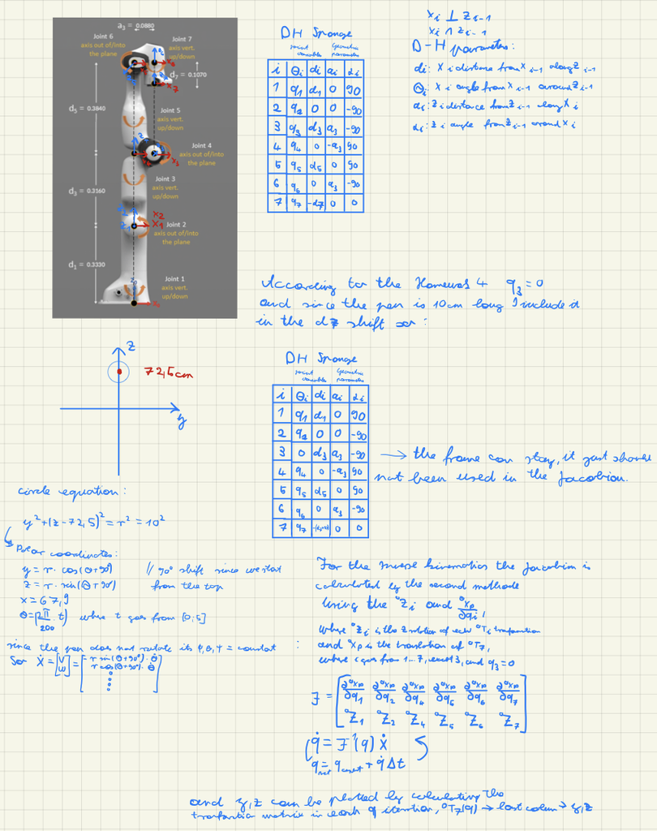

```python
Image("Doc.png")
```

```python
q1,q2,q3,q4,q5,q6,q7,d1,d3,d5,d7,a3=symbols('q_1 q_2 q_3 q_4 q_5 q_6 q_7 d_1 d_3 d_5 d_7 a_3') #symbols
```

The transformation matrixes are calculated.

```python
def DH_Tr_sym_UMD(theta=0, d=0 , a=0, alpha=0):
    Tr_theta=Matrix([[cos(theta),-sin(theta),0,0],
                       [sin(theta),cos(theta),0,0],
                       [0,0,1,0],
                       [0,0,0,1]])
    Tr_d=Matrix([[1,0,0,0],
                   [0,1,0,0],
                   [0,0,1,d],
                   [0,0,0,1]])
    Tr_a=Matrix([[1,0,0,a],
                   [0,1,0,0],
                   [0,0,1,0],
                   [0,0,0,1]])
    Tr_alpha=Matrix([[1,0,0,0],
                       [0,cos(alpha),-sin(alpha),0],
                       [0,sin(alpha) ,cos(alpha),0],
                       [0,0,0,1]])


    Tr_KHALIL=Tr_theta@Tr_d@Tr_a@Tr_alpha

    return Tr_KHALIL
```

```python
H_01=DH_Tr_sym_UMD(theta=q1, d=d1 , a=0, alpha=pi/2)
H_01
```

$\displaystyle \left[\begin{matrix}\cos{\left(q_{1} \right)} & 0 & \sin{\left(q_{1} \right)} & 0\\\sin{\left(q_{1} \right)} & 0 & - \cos{\left(q_{1} \right)} & 0\\0 & 1 & 0 & d_{1}\\0 & 0 & 0 & 1\end{matrix}\right]$

```python
H_12=DH_Tr_sym_UMD(theta=q2, d=0 , a=0, alpha=-pi/2)
H_02=H_01@H_12
H_02
```

$\displaystyle \left[\begin{matrix}\cos{\left(q_{1} \right)} \cos{\left(q_{2} \right)} & - \sin{\left(q_{1} \right)} & - \sin{\left(q_{2} \right)} \cos{\left(q_{1} \right)} & 0\\\sin{\left(q_{1} \right)} \cos{\left(q_{2} \right)} & \cos{\left(q_{1} \right)} & - \sin{\left(q_{1} \right)} \sin{\left(q_{2} \right)} & 0\\\sin{\left(q_{2} \right)} & 0 & \cos{\left(q_{2} \right)} & d_{1}\\0 & 0 & 0 & 1\end{matrix}\right]$

```python
H_23=DH_Tr_sym_UMD(theta=q3, d=d3 , a=a3, alpha=-pi/2)
H_03=H_01@H_12@H_23
H_03
```

$\displaystyle \left[\begin{matrix}- \sin{\left(q_{1} \right)} \sin{\left(q_{3} \right)} + \cos{\left(q_{1} \right)} \cos{\left(q_{2} \right)} \cos{\left(q_{3} \right)} & \sin{\left(q_{2} \right)} \cos{\left(q_{1} \right)} & - \sin{\left(q_{1} \right)} \cos{\left(q_{3} \right)} - \sin{\left(q_{3} \right)} \cos{\left(q_{1} \right)} \cos{\left(q_{2} \right)} & - a_{3} \sin{\left(q_{1} \right)} \sin{\left(q_{3} \right)} + a_{3} \cos{\left(q_{1} \right)} \cos{\left(q_{2} \right)} \cos{\left(q_{3} \right)} - d_{3} \sin{\left(q_{2} \right)} \cos{\left(q_{1} \right)}\\\sin{\left(q_{1} \right)} \cos{\left(q_{2} \right)} \cos{\left(q_{3} \right)} + \sin{\left(q_{3} \right)} \cos{\left(q_{1} \right)} & \sin{\left(q_{1} \right)} \sin{\left(q_{2} \right)} & - \sin{\left(q_{1} \right)} \sin{\left(q_{3} \right)} \cos{\left(q_{2} \right)} + \cos{\left(q_{1} \right)} \cos{\left(q_{3} \right)} & a_{3} \sin{\left(q_{1} \right)} \cos{\left(q_{2} \right)} \cos{\left(q_{3} \right)} + a_{3} \sin{\left(q_{3} \right)} \cos{\left(q_{1} \right)} - d_{3} \sin{\left(q_{1} \right)} \sin{\left(q_{2} \right)}\\\sin{\left(q_{2} \right)} \cos{\left(q_{3} \right)} & - \cos{\left(q_{2} \right)} & - \sin{\left(q_{2} \right)} \sin{\left(q_{3} \right)} & a_{3} \sin{\left(q_{2} \right)} \cos{\left(q_{3} \right)} + d_{1} + d_{3} \cos{\left(q_{2} \right)}\\0 & 0 & 0 & 1\end{matrix}\right]$

```python
H_34=DH_Tr_sym_UMD(theta=q4, d=0 , a=-a3, alpha=pi/2)
H_04=H_01@H_12@H_23@H_34
H_34
```

$\displaystyle \left[\begin{matrix}\cos{\left(q_{4} \right)} & 0 & \sin{\left(q_{4} \right)} & - a_{3} \cos{\left(q_{4} \right)}\\\sin{\left(q_{4} \right)} & 0 & - \cos{\left(q_{4} \right)} & - a_{3} \sin{\left(q_{4} \right)}\\0 & 1 & 0 & 0\\0 & 0 & 0 & 1\end{matrix}\right]$

```python
H_45=DH_Tr_sym_UMD(theta=q5, d=d5 , a=0, alpha=pi/2)
H_05=H_01@H_12@H_23@H_34@H_45
H_45
```

$\displaystyle \left[\begin{matrix}\cos{\left(q_{5} \right)} & 0 & \sin{\left(q_{5} \right)} & 0\\\sin{\left(q_{5} \right)} & 0 & - \cos{\left(q_{5} \right)} & 0\\0 & 1 & 0 & d_{5}\\0 & 0 & 0 & 1\end{matrix}\right]$

```python
H_56=DH_Tr_sym_UMD(theta=q6, d=0 , a=a3, alpha=-pi/2)
H_06=H_01@H_12@H_23@H_34@H_45@H_56
H_56
```

$\displaystyle \left[\begin{matrix}\cos{\left(q_{6} \right)} & 0 & - \sin{\left(q_{6} \right)} & a_{3} \cos{\left(q_{6} \right)}\\\sin{\left(q_{6} \right)} & 0 & \cos{\left(q_{6} \right)} & a_{3} \sin{\left(q_{6} \right)}\\0 & -1 & 0 & 0\\0 & 0 & 0 & 1\end{matrix}\right]$

```python
H_67=DH_Tr_sym_UMD(theta=q7, d=-d7 , a=0, alpha=0)
H_07=H_06*H_67
H_67
H_07
```

$\displaystyle \left[\begin{matrix}\left(\left(\left(\left(- \sin{\left(q_{1} \right)} \sin{\left(q_{3} \right)} + \cos{\left(q_{1} \right)} \cos{\left(q_{2} \right)} \cos{\left(q_{3} \right)}\right) \cos{\left(q_{4} \right)} + \sin{\left(q_{2} \right)} \sin{\left(q_{4} \right)} \cos{\left(q_{1} \right)}\right) \cos{\left(q_{5} \right)} + \left(- \sin{\left(q_{1} \right)} \cos{\left(q_{3} \right)} - \sin{\left(q_{3} \right)} \cos{\left(q_{1} \right)} \cos{\left(q_{2} \right)}\right) \sin{\left(q_{5} \right)}\right) \cos{\left(q_{6} \right)} + \left(\left(- \sin{\left(q_{1} \right)} \sin{\left(q_{3} \right)} + \cos{\left(q_{1} \right)} \cos{\left(q_{2} \right)} \cos{\left(q_{3} \right)}\right) \sin{\left(q_{4} \right)} - \sin{\left(q_{2} \right)} \cos{\left(q_{1} \right)} \cos{\left(q_{4} \right)}\right) \sin{\left(q_{6} \right)}\right) \cos{\left(q_{7} \right)} + \left(- \left(\left(- \sin{\left(q_{1} \right)} \sin{\left(q_{3} \right)} + \cos{\left(q_{1} \right)} \cos{\left(q_{2} \right)} \cos{\left(q_{3} \right)}\right) \cos{\left(q_{4} \right)} + \sin{\left(q_{2} \right)} \sin{\left(q_{4} \right)} \cos{\left(q_{1} \right)}\right) \sin{\left(q_{5} \right)} + \left(- \sin{\left(q_{1} \right)} \cos{\left(q_{3} \right)} - \sin{\left(q_{3} \right)} \cos{\left(q_{1} \right)} \cos{\left(q_{2} \right)}\right) \cos{\left(q_{5} \right)}\right) \sin{\left(q_{7} \right)} & - \left(\left(\left(\left(- \sin{\left(q_{1} \right)} \sin{\left(q_{3} \right)} + \cos{\left(q_{1} \right)} \cos{\left(q_{2} \right)} \cos{\left(q_{3} \right)}\right) \cos{\left(q_{4} \right)} + \sin{\left(q_{2} \right)} \sin{\left(q_{4} \right)} \cos{\left(q_{1} \right)}\right) \cos{\left(q_{5} \right)} + \left(- \sin{\left(q_{1} \right)} \cos{\left(q_{3} \right)} - \sin{\left(q_{3} \right)} \cos{\left(q_{1} \right)} \cos{\left(q_{2} \right)}\right) \sin{\left(q_{5} \right)}\right) \cos{\left(q_{6} \right)} + \left(\left(- \sin{\left(q_{1} \right)} \sin{\left(q_{3} \right)} + \cos{\left(q_{1} \right)} \cos{\left(q_{2} \right)} \cos{\left(q_{3} \right)}\right) \sin{\left(q_{4} \right)} - \sin{\left(q_{2} \right)} \cos{\left(q_{1} \right)} \cos{\left(q_{4} \right)}\right) \sin{\left(q_{6} \right)}\right) \sin{\left(q_{7} \right)} + \left(- \left(\left(- \sin{\left(q_{1} \right)} \sin{\left(q_{3} \right)} + \cos{\left(q_{1} \right)} \cos{\left(q_{2} \right)} \cos{\left(q_{3} \right)}\right) \cos{\left(q_{4} \right)} + \sin{\left(q_{2} \right)} \sin{\left(q_{4} \right)} \cos{\left(q_{1} \right)}\right) \sin{\left(q_{5} \right)} + \left(- \sin{\left(q_{1} \right)} \cos{\left(q_{3} \right)} - \sin{\left(q_{3} \right)} \cos{\left(q_{1} \right)} \cos{\left(q_{2} \right)}\right) \cos{\left(q_{5} \right)}\right) \cos{\left(q_{7} \right)} & - \left(\left(\left(- \sin{\left(q_{1} \right)} \sin{\left(q_{3} \right)} + \cos{\left(q_{1} \right)} \cos{\left(q_{2} \right)} \cos{\left(q_{3} \right)}\right) \cos{\left(q_{4} \right)} + \sin{\left(q_{2} \right)} \sin{\left(q_{4} \right)} \cos{\left(q_{1} \ri…

```python
H_07.subs({q3:0})[2,3]
```

$\displaystyle a_{3} \left(\sin{\left(q_{2} \right)} \sin{\left(q_{4} \right)} + \cos{\left(q_{2} \right)} \cos{\left(q_{4} \right)}\right) \sin{\left(q_{6} \right)} + a_{3} \left(\sin{\left(q_{2} \right)} \cos{\left(q_{4} \right)} - \sin{\left(q_{4} \right)} \cos{\left(q_{2} \right)}\right) \cos{\left(q_{5} \right)} \cos{\left(q_{6} \right)} - a_{3} \sin{\left(q_{2} \right)} \cos{\left(q_{4} \right)} + a_{3} \sin{\left(q_{2} \right)} + a_{3} \sin{\left(q_{4} \right)} \cos{\left(q_{2} \right)} + d_{1} + d_{3} \cos{\left(q_{2} \right)} + d_{5} \left(\sin{\left(q_{2} \right)} \sin{\left(q_{4} \right)} + \cos{\left(q_{2} \right)} \cos{\left(q_{4} \right)}\right) - d_{7} \left(\left(\sin{\left(q_{2} \right)} \sin{\left(q_{4} \right)} + \cos{\left(q_{2} \right)} \cos{\left(q_{4} \right)}\right) \cos{\left(q_{6} \right)} - \left(\sin{\left(q_{2} \right)} \cos{\left(q_{4} \right)} - \sin{\left(q_{4} \right)} \cos{\left(q_{2} \right)}\right) \sin{\left(q_{6} \right)} \cos{\left(q_{5} \right)}\right)$

```python
H_07_inv=H_07 #made a copy to use it later on
```

```python
H_07
```

$\displaystyle \left[\begin{matrix}\left(\left(\left(\left(- \sin{\left(q_{1} \right)} \sin{\left(q_{3} \right)} + \cos{\left(q_{1} \right)} \cos{\left(q_{2} \right)} \cos{\left(q_{3} \right)}\right) \cos{\left(q_{4} \right)} + \sin{\left(q_{2} \right)} \sin{\left(q_{4} \right)} \cos{\left(q_{1} \right)}\right) \cos{\left(q_{5} \right)} + \left(- \sin{\left(q_{1} \right)} \cos{\left(q_{3} \right)} - \sin{\left(q_{3} \right)} \cos{\left(q_{1} \right)} \cos{\left(q_{2} \right)}\right) \sin{\left(q_{5} \right)}\right) \cos{\left(q_{6} \right)} + \left(\left(- \sin{\left(q_{1} \right)} \sin{\left(q_{3} \right)} + \cos{\left(q_{1} \right)} \cos{\left(q_{2} \right)} \cos{\left(q_{3} \right)}\right) \sin{\left(q_{4} \right)} - \sin{\left(q_{2} \right)} \cos{\left(q_{1} \right)} \cos{\left(q_{4} \right)}\right) \sin{\left(q_{6} \right)}\right) \cos{\left(q_{7} \right)} + \left(- \left(\left(- \sin{\left(q_{1} \right)} \sin{\left(q_{3} \right)} + \cos{\left(q_{1} \right)} \cos{\left(q_{2} \right)} \cos{\left(q_{3} \right)}\right) \cos{\left(q_{4} \right)} + \sin{\left(q_{2} \right)} \sin{\left(q_{4} \right)} \cos{\left(q_{1} \right)}\right) \sin{\left(q_{5} \right)} + \left(- \sin{\left(q_{1} \right)} \cos{\left(q_{3} \right)} - \sin{\left(q_{3} \right)} \cos{\left(q_{1} \right)} \cos{\left(q_{2} \right)}\right) \cos{\left(q_{5} \right)}\right) \sin{\left(q_{7} \right)} & - \left(\left(\left(\left(- \sin{\left(q_{1} \right)} \sin{\left(q_{3} \right)} + \cos{\left(q_{1} \right)} \cos{\left(q_{2} \right)} \cos{\left(q_{3} \right)}\right) \cos{\left(q_{4} \right)} + \sin{\left(q_{2} \right)} \sin{\left(q_{4} \right)} \cos{\left(q_{1} \right)}\right) \cos{\left(q_{5} \right)} + \left(- \sin{\left(q_{1} \right)} \cos{\left(q_{3} \right)} - \sin{\left(q_{3} \right)} \cos{\left(q_{1} \right)} \cos{\left(q_{2} \right)}\right) \sin{\left(q_{5} \right)}\right) \cos{\left(q_{6} \right)} + \left(\left(- \sin{\left(q_{1} \right)} \sin{\left(q_{3} \right)} + \cos{\left(q_{1} \right)} \cos{\left(q_{2} \right)} \cos{\left(q_{3} \right)}\right) \sin{\left(q_{4} \right)} - \sin{\left(q_{2} \right)} \cos{\left(q_{1} \right)} \cos{\left(q_{4} \right)}\right) \sin{\left(q_{6} \right)}\right) \sin{\left(q_{7} \right)} + \left(- \left(\left(- \sin{\left(q_{1} \right)} \sin{\left(q_{3} \right)} + \cos{\left(q_{1} \right)} \cos{\left(q_{2} \right)} \cos{\left(q_{3} \right)}\right) \cos{\left(q_{4} \right)} + \sin{\left(q_{2} \right)} \sin{\left(q_{4} \right)} \cos{\left(q_{1} \right)}\right) \sin{\left(q_{5} \right)} + \left(- \sin{\left(q_{1} \right)} \cos{\left(q_{3} \right)} - \sin{\left(q_{3} \right)} \cos{\left(q_{1} \right)} \cos{\left(q_{2} \right)}\right) \cos{\left(q_{5} \right)}\right) \cos{\left(q_{7} \right)} & - \left(\left(\left(- \sin{\left(q_{1} \right)} \sin{\left(q_{3} \right)} + \cos{\left(q_{1} \right)} \cos{\left(q_{2} \right)} \cos{\left(q_{3} \right)}\right) \cos{\left(q_{4} \right)} + \sin{\left(q_{2} \right)} \sin{\left(q_{4} \right)} \cos{\left(q_{1} \ri…

Generating $X_p$

```python
X_p=(H_07.col(-1))
X_p
```

$\displaystyle \left[\begin{matrix}a_{3} \left(\left(\left(- \sin{\left(q_{1} \right)} \sin{\left(q_{3} \right)} + \cos{\left(q_{1} \right)} \cos{\left(q_{2} \right)} \cos{\left(q_{3} \right)}\right) \cos{\left(q_{4} \right)} + \sin{\left(q_{2} \right)} \sin{\left(q_{4} \right)} \cos{\left(q_{1} \right)}\right) \cos{\left(q_{5} \right)} + \left(- \sin{\left(q_{1} \right)} \cos{\left(q_{3} \right)} - \sin{\left(q_{3} \right)} \cos{\left(q_{1} \right)} \cos{\left(q_{2} \right)}\right) \sin{\left(q_{5} \right)}\right) \cos{\left(q_{6} \right)} + a_{3} \left(\left(- \sin{\left(q_{1} \right)} \sin{\left(q_{3} \right)} + \cos{\left(q_{1} \right)} \cos{\left(q_{2} \right)} \cos{\left(q_{3} \right)}\right) \sin{\left(q_{4} \right)} - \sin{\left(q_{2} \right)} \cos{\left(q_{1} \right)} \cos{\left(q_{4} \right)}\right) \sin{\left(q_{6} \right)} - a_{3} \left(- \sin{\left(q_{1} \right)} \sin{\left(q_{3} \right)} + \cos{\left(q_{1} \right)} \cos{\left(q_{2} \right)} \cos{\left(q_{3} \right)}\right) \cos{\left(q_{4} \right)} - a_{3} \sin{\left(q_{1} \right)} \sin{\left(q_{3} \right)} - a_{3} \sin{\left(q_{2} \right)} \sin{\left(q_{4} \right)} \cos{\left(q_{1} \right)} + a_{3} \cos{\left(q_{1} \right)} \cos{\left(q_{2} \right)} \cos{\left(q_{3} \right)} - d_{3} \sin{\left(q_{2} \right)} \cos{\left(q_{1} \right)} + d_{5} \left(\left(- \sin{\left(q_{1} \right)} \sin{\left(q_{3} \right)} + \cos{\left(q_{1} \right)} \cos{\left(q_{2} \right)} \cos{\left(q_{3} \right)}\right) \sin{\left(q_{4} \right)} - \sin{\left(q_{2} \right)} \cos{\left(q_{1} \right)} \cos{\left(q_{4} \right)}\right) - d_{7} \left(- \left(\left(\left(- \sin{\left(q_{1} \right)} \sin{\left(q_{3} \right)} + \cos{\left(q_{1} \right)} \cos{\left(q_{2} \right)} \cos{\left(q_{3} \right)}\right) \cos{\left(q_{4} \right)} + \sin{\left(q_{2} \right)} \sin{\left(q_{4} \right)} \cos{\left(q_{1} \right)}\right) \cos{\left(q_{5} \right)} + \left(- \sin{\left(q_{1} \right)} \cos{\left(q_{3} \right)} - \sin{\left(q_{3} \right)} \cos{\left(q_{1} \right)} \cos{\left(q_{2} \right)}\right) \sin{\left(q_{5} \right)}\right) \sin{\left(q_{6} \right)} + \left(\left(- \sin{\left(q_{1} \right)} \sin{\left(q_{3} \right)} + \cos{\left(q_{1} \right)} \cos{\left(q_{2} \right)} \cos{\left(q_{3} \right)}\right) \sin{\left(q_{4} \right)} - \sin{\left(q_{2} \right)} \cos{\left(q_{1} \right)} \cos{\left(q_{4} \right)}\right) \cos{\left(q_{6} \right)}\right)\\a_{3} \left(\left(\left(\sin{\left(q_{1} \right)} \cos{\left(q_{2} \right)} \cos{\left(q_{3} \right)} + \sin{\left(q_{3} \right)} \cos{\left(q_{1} \right)}\right) \cos{\left(q_{4} \right)} + \sin{\left(q_{1} \right)} \sin{\left(q_{2} \right)} \sin{\left(q_{4} \right)}\right) \cos{\left(q_{5} \right)} + \left(- \sin{\left(q_{1} \right)} \sin{\left(q_{3} \right)} \cos{\left(q_{2} \right)} + \cos{\left(q_{1} \right)} \cos{\left(q_{3} \right)}\right) \sin{\left(q_{5} \right)}\right) \cos{\left(q_{6} \right)} + a_{3} \left(\left(\sin{\left(q_{1} \right)} \cos{\left(q_{2} \right)} …

```python
X_p.row_del(-1)
```

```python
X_p
```

$\displaystyle \left[\begin{matrix}a_{3} \left(\left(\left(- \sin{\left(q_{1} \right)} \sin{\left(q_{3} \right)} + \cos{\left(q_{1} \right)} \cos{\left(q_{2} \right)} \cos{\left(q_{3} \right)}\right) \cos{\left(q_{4} \right)} + \sin{\left(q_{2} \right)} \sin{\left(q_{4} \right)} \cos{\left(q_{1} \right)}\right) \cos{\left(q_{5} \right)} + \left(- \sin{\left(q_{1} \right)} \cos{\left(q_{3} \right)} - \sin{\left(q_{3} \right)} \cos{\left(q_{1} \right)} \cos{\left(q_{2} \right)}\right) \sin{\left(q_{5} \right)}\right) \cos{\left(q_{6} \right)} + a_{3} \left(\left(- \sin{\left(q_{1} \right)} \sin{\left(q_{3} \right)} + \cos{\left(q_{1} \right)} \cos{\left(q_{2} \right)} \cos{\left(q_{3} \right)}\right) \sin{\left(q_{4} \right)} - \sin{\left(q_{2} \right)} \cos{\left(q_{1} \right)} \cos{\left(q_{4} \right)}\right) \sin{\left(q_{6} \right)} - a_{3} \left(- \sin{\left(q_{1} \right)} \sin{\left(q_{3} \right)} + \cos{\left(q_{1} \right)} \cos{\left(q_{2} \right)} \cos{\left(q_{3} \right)}\right) \cos{\left(q_{4} \right)} - a_{3} \sin{\left(q_{1} \right)} \sin{\left(q_{3} \right)} - a_{3} \sin{\left(q_{2} \right)} \sin{\left(q_{4} \right)} \cos{\left(q_{1} \right)} + a_{3} \cos{\left(q_{1} \right)} \cos{\left(q_{2} \right)} \cos{\left(q_{3} \right)} - d_{3} \sin{\left(q_{2} \right)} \cos{\left(q_{1} \right)} + d_{5} \left(\left(- \sin{\left(q_{1} \right)} \sin{\left(q_{3} \right)} + \cos{\left(q_{1} \right)} \cos{\left(q_{2} \right)} \cos{\left(q_{3} \right)}\right) \sin{\left(q_{4} \right)} - \sin{\left(q_{2} \right)} \cos{\left(q_{1} \right)} \cos{\left(q_{4} \right)}\right) - d_{7} \left(- \left(\left(\left(- \sin{\left(q_{1} \right)} \sin{\left(q_{3} \right)} + \cos{\left(q_{1} \right)} \cos{\left(q_{2} \right)} \cos{\left(q_{3} \right)}\right) \cos{\left(q_{4} \right)} + \sin{\left(q_{2} \right)} \sin{\left(q_{4} \right)} \cos{\left(q_{1} \right)}\right) \cos{\left(q_{5} \right)} + \left(- \sin{\left(q_{1} \right)} \cos{\left(q_{3} \right)} - \sin{\left(q_{3} \right)} \cos{\left(q_{1} \right)} \cos{\left(q_{2} \right)}\right) \sin{\left(q_{5} \right)}\right) \sin{\left(q_{6} \right)} + \left(\left(- \sin{\left(q_{1} \right)} \sin{\left(q_{3} \right)} + \cos{\left(q_{1} \right)} \cos{\left(q_{2} \right)} \cos{\left(q_{3} \right)}\right) \sin{\left(q_{4} \right)} - \sin{\left(q_{2} \right)} \cos{\left(q_{1} \right)} \cos{\left(q_{4} \right)}\right) \cos{\left(q_{6} \right)}\right)\\a_{3} \left(\left(\left(\sin{\left(q_{1} \right)} \cos{\left(q_{2} \right)} \cos{\left(q_{3} \right)} + \sin{\left(q_{3} \right)} \cos{\left(q_{1} \right)}\right) \cos{\left(q_{4} \right)} + \sin{\left(q_{1} \right)} \sin{\left(q_{2} \right)} \sin{\left(q_{4} \right)}\right) \cos{\left(q_{5} \right)} + \left(- \sin{\left(q_{1} \right)} \sin{\left(q_{3} \right)} \cos{\left(q_{2} \right)} + \cos{\left(q_{1} \right)} \cos{\left(q_{3} \right)}\right) \sin{\left(q_{5} \right)}\right) \cos{\left(q_{6} \right)} + a_{3} \left(\left(\sin{\left(q_{1} \right)} \cos{\left(q_{2} \right)} …

Canculating the velocity part of the Jacobian, by differentiating $X_p$, you can see the components by order in the matrix.

```python
J_v = X_p.diff(q1).row_join(X_p.diff(q2)).row_join(X_p.diff(q4)).row_join(X_p.diff(q5)).row_join(X_p.diff(q6)).row_join(X_p.diff(q7))
```

```python
J_v
```

$\displaystyle \left[\begin{matrix}a_{3} \left(\left(\left(- \sin{\left(q_{1} \right)} \cos{\left(q_{2} \right)} \cos{\left(q_{3} \right)} - \sin{\left(q_{3} \right)} \cos{\left(q_{1} \right)}\right) \cos{\left(q_{4} \right)} - \sin{\left(q_{1} \right)} \sin{\left(q_{2} \right)} \sin{\left(q_{4} \right)}\right) \cos{\left(q_{5} \right)} + \left(\sin{\left(q_{1} \right)} \sin{\left(q_{3} \right)} \cos{\left(q_{2} \right)} - \cos{\left(q_{1} \right)} \cos{\left(q_{3} \right)}\right) \sin{\left(q_{5} \right)}\right) \cos{\left(q_{6} \right)} + a_{3} \left(\left(- \sin{\left(q_{1} \right)} \cos{\left(q_{2} \right)} \cos{\left(q_{3} \right)} - \sin{\left(q_{3} \right)} \cos{\left(q_{1} \right)}\right) \sin{\left(q_{4} \right)} + \sin{\left(q_{1} \right)} \sin{\left(q_{2} \right)} \cos{\left(q_{4} \right)}\right) \sin{\left(q_{6} \right)} - a_{3} \left(- \sin{\left(q_{1} \right)} \cos{\left(q_{2} \right)} \cos{\left(q_{3} \right)} - \sin{\left(q_{3} \right)} \cos{\left(q_{1} \right)}\right) \cos{\left(q_{4} \right)} + a_{3} \sin{\left(q_{1} \right)} \sin{\left(q_{2} \right)} \sin{\left(q_{4} \right)} - a_{3} \sin{\left(q_{1} \right)} \cos{\left(q_{2} \right)} \cos{\left(q_{3} \right)} - a_{3} \sin{\left(q_{3} \right)} \cos{\left(q_{1} \right)} + d_{3} \sin{\left(q_{1} \right)} \sin{\left(q_{2} \right)} + d_{5} \left(\left(- \sin{\left(q_{1} \right)} \cos{\left(q_{2} \right)} \cos{\left(q_{3} \right)} - \sin{\left(q_{3} \right)} \cos{\left(q_{1} \right)}\right) \sin{\left(q_{4} \right)} + \sin{\left(q_{1} \right)} \sin{\left(q_{2} \right)} \cos{\left(q_{4} \right)}\right) - d_{7} \left(\left(- \left(\left(- \sin{\left(q_{1} \right)} \cos{\left(q_{2} \right)} \cos{\left(q_{3} \right)} - \sin{\left(q_{3} \right)} \cos{\left(q_{1} \right)}\right) \cos{\left(q_{4} \right)} - \sin{\left(q_{1} \right)} \sin{\left(q_{2} \right)} \sin{\left(q_{4} \right)}\right) \cos{\left(q_{5} \right)} - \left(\sin{\left(q_{1} \right)} \sin{\left(q_{3} \right)} \cos{\left(q_{2} \right)} - \cos{\left(q_{1} \right)} \cos{\left(q_{3} \right)}\right) \sin{\left(q_{5} \right)}\right) \sin{\left(q_{6} \right)} + \left(\left(- \sin{\left(q_{1} \right)} \cos{\left(q_{2} \right)} \cos{\left(q_{3} \right)} - \sin{\left(q_{3} \right)} \cos{\left(q_{1} \right)}\right) \sin{\left(q_{4} \right)} + \sin{\left(q_{1} \right)} \sin{\left(q_{2} \right)} \cos{\left(q_{4} \right)}\right) \cos{\left(q_{6} \right)}\right) & a_{3} \left(\left(- \sin{\left(q_{2} \right)} \cos{\left(q_{1} \right)} \cos{\left(q_{3} \right)} \cos{\left(q_{4} \right)} + \sin{\left(q_{4} \right)} \cos{\left(q_{1} \right)} \cos{\left(q_{2} \right)}\right) \cos{\left(q_{5} \right)} + \sin{\left(q_{2} \right)} \sin{\left(q_{3} \right)} \sin{\left(q_{5} \right)} \cos{\left(q_{1} \right)}\right) \cos{\left(q_{6} \right)} + a_{3} \left(- \sin{\left(q_{2} \right)} \sin{\left(q_{4} \right)} \cos{\left(q_{1} \right)} \cos{\left(q_{3} \right)} - \cos{\left(q_{1} \right)} \cos{\left(q_{2} \right)} \cos{\left(q_{4} \right)}\right) \s…

Generating the angular velocity part of the Jacobian by collceting the $Z$-rotations from the corresponding transformation matrices. You can see the conponents by order in the matrix.

```python
J_w=H_01.col(2).row_join(H_02.col(2)).row_join(H_04.col(2)).row_join(H_05.col(2)).row_join(H_06.col(2)).row_join(H_07.col(2))
J_w
```

$\displaystyle \left[\begin{matrix}\sin{\left(q_{1} \right)} & - \sin{\left(q_{2} \right)} \cos{\left(q_{1} \right)} & \left(- \sin{\left(q_{1} \right)} \sin{\left(q_{3} \right)} + \cos{\left(q_{1} \right)} \cos{\left(q_{2} \right)} \cos{\left(q_{3} \right)}\right) \sin{\left(q_{4} \right)} - \sin{\left(q_{2} \right)} \cos{\left(q_{1} \right)} \cos{\left(q_{4} \right)} & \left(\left(- \sin{\left(q_{1} \right)} \sin{\left(q_{3} \right)} + \cos{\left(q_{1} \right)} \cos{\left(q_{2} \right)} \cos{\left(q_{3} \right)}\right) \cos{\left(q_{4} \right)} + \sin{\left(q_{2} \right)} \sin{\left(q_{4} \right)} \cos{\left(q_{1} \right)}\right) \sin{\left(q_{5} \right)} - \left(- \sin{\left(q_{1} \right)} \cos{\left(q_{3} \right)} - \sin{\left(q_{3} \right)} \cos{\left(q_{1} \right)} \cos{\left(q_{2} \right)}\right) \cos{\left(q_{5} \right)} & - \left(\left(\left(- \sin{\left(q_{1} \right)} \sin{\left(q_{3} \right)} + \cos{\left(q_{1} \right)} \cos{\left(q_{2} \right)} \cos{\left(q_{3} \right)}\right) \cos{\left(q_{4} \right)} + \sin{\left(q_{2} \right)} \sin{\left(q_{4} \right)} \cos{\left(q_{1} \right)}\right) \cos{\left(q_{5} \right)} + \left(- \sin{\left(q_{1} \right)} \cos{\left(q_{3} \right)} - \sin{\left(q_{3} \right)} \cos{\left(q_{1} \right)} \cos{\left(q_{2} \right)}\right) \sin{\left(q_{5} \right)}\right) \sin{\left(q_{6} \right)} + \left(\left(- \sin{\left(q_{1} \right)} \sin{\left(q_{3} \right)} + \cos{\left(q_{1} \right)} \cos{\left(q_{2} \right)} \cos{\left(q_{3} \right)}\right) \sin{\left(q_{4} \right)} - \sin{\left(q_{2} \right)} \cos{\left(q_{1} \right)} \cos{\left(q_{4} \right)}\right) \cos{\left(q_{6} \right)} & - \left(\left(\left(- \sin{\left(q_{1} \right)} \sin{\left(q_{3} \right)} + \cos{\left(q_{1} \right)} \cos{\left(q_{2} \right)} \cos{\left(q_{3} \right)}\right) \cos{\left(q_{4} \right)} + \sin{\left(q_{2} \right)} \sin{\left(q_{4} \right)} \cos{\left(q_{1} \right)}\right) \cos{\left(q_{5} \right)} + \left(- \sin{\left(q_{1} \right)} \cos{\left(q_{3} \right)} - \sin{\left(q_{3} \right)} \cos{\left(q_{1} \right)} \cos{\left(q_{2} \right)}\right) \sin{\left(q_{5} \right)}\right) \sin{\left(q_{6} \right)} + \left(\left(- \sin{\left(q_{1} \right)} \sin{\left(q_{3} \right)} + \cos{\left(q_{1} \right)} \cos{\left(q_{2} \right)} \cos{\left(q_{3} \right)}\right) \sin{\left(q_{4} \right)} - \sin{\left(q_{2} \right)} \cos{\left(q_{1} \right)} \cos{\left(q_{4} \right)}\right) \cos{\left(q_{6} \right)}\\- \cos{\left(q_{1} \right)} & - \sin{\left(q_{1} \right)} \sin{\left(q_{2} \right)} & \left(\sin{\left(q_{1} \right)} \cos{\left(q_{2} \right)} \cos{\left(q_{3} \right)} + \sin{\left(q_{3} \right)} \cos{\left(q_{1} \right)}\right) \sin{\left(q_{4} \right)} - \sin{\left(q_{1} \right)} \sin{\left(q_{2} \right)} \cos{\left(q_{4} \right)} & \left(\left(\sin{\left(q_{1} \right)} \cos{\left(q_{2} \right)} \cos{\left(q_{3} \right)} + \sin{\left(q_{3} \right)} \cos{\left(q_{1} \right)}\right) \cos{\left(q_{4} \right)} + \sin{\left(q_{1} \right)} \sin{\…

Building the Jacobian called $M$

```python
J_w.row_del(-1)
```

```python
M=J_v.col_join(J_w)
```

```python
M=M.subs({q3:0})
M
```

$\displaystyle \left[\begin{matrix}a_{3} \left(\left(- \sin{\left(q_{1} \right)} \sin{\left(q_{2} \right)} \sin{\left(q_{4} \right)} - \sin{\left(q_{1} \right)} \cos{\left(q_{2} \right)} \cos{\left(q_{4} \right)}\right) \cos{\left(q_{5} \right)} - \sin{\left(q_{5} \right)} \cos{\left(q_{1} \right)}\right) \cos{\left(q_{6} \right)} + a_{3} \left(\sin{\left(q_{1} \right)} \sin{\left(q_{2} \right)} \cos{\left(q_{4} \right)} - \sin{\left(q_{1} \right)} \sin{\left(q_{4} \right)} \cos{\left(q_{2} \right)}\right) \sin{\left(q_{6} \right)} + a_{3} \sin{\left(q_{1} \right)} \sin{\left(q_{2} \right)} \sin{\left(q_{4} \right)} + a_{3} \sin{\left(q_{1} \right)} \cos{\left(q_{2} \right)} \cos{\left(q_{4} \right)} - a_{3} \sin{\left(q_{1} \right)} \cos{\left(q_{2} \right)} + d_{3} \sin{\left(q_{1} \right)} \sin{\left(q_{2} \right)} + d_{5} \left(\sin{\left(q_{1} \right)} \sin{\left(q_{2} \right)} \cos{\left(q_{4} \right)} - \sin{\left(q_{1} \right)} \sin{\left(q_{4} \right)} \cos{\left(q_{2} \right)}\right) - d_{7} \left(\left(- \left(- \sin{\left(q_{1} \right)} \sin{\left(q_{2} \right)} \sin{\left(q_{4} \right)} - \sin{\left(q_{1} \right)} \cos{\left(q_{2} \right)} \cos{\left(q_{4} \right)}\right) \cos{\left(q_{5} \right)} + \sin{\left(q_{5} \right)} \cos{\left(q_{1} \right)}\right) \sin{\left(q_{6} \right)} + \left(\sin{\left(q_{1} \right)} \sin{\left(q_{2} \right)} \cos{\left(q_{4} \right)} - \sin{\left(q_{1} \right)} \sin{\left(q_{4} \right)} \cos{\left(q_{2} \right)}\right) \cos{\left(q_{6} \right)}\right) & a_{3} \left(- \sin{\left(q_{2} \right)} \sin{\left(q_{4} \right)} \cos{\left(q_{1} \right)} - \cos{\left(q_{1} \right)} \cos{\left(q_{2} \right)} \cos{\left(q_{4} \right)}\right) \sin{\left(q_{6} \right)} + a_{3} \left(- \sin{\left(q_{2} \right)} \cos{\left(q_{1} \right)} \cos{\left(q_{4} \right)} + \sin{\left(q_{4} \right)} \cos{\left(q_{1} \right)} \cos{\left(q_{2} \right)}\right) \cos{\left(q_{5} \right)} \cos{\left(q_{6} \right)} + a_{3} \sin{\left(q_{2} \right)} \cos{\left(q_{1} \right)} \cos{\left(q_{4} \right)} - a_{3} \sin{\left(q_{2} \right)} \cos{\left(q_{1} \right)} - a_{3} \sin{\left(q_{4} \right)} \cos{\left(q_{1} \right)} \cos{\left(q_{2} \right)} - d_{3} \cos{\left(q_{1} \right)} \cos{\left(q_{2} \right)} + d_{5} \left(- \sin{\left(q_{2} \right)} \sin{\left(q_{4} \right)} \cos{\left(q_{1} \right)} - \cos{\left(q_{1} \right)} \cos{\left(q_{2} \right)} \cos{\left(q_{4} \right)}\right) - d_{7} \left(\left(- \sin{\left(q_{2} \right)} \sin{\left(q_{4} \right)} \cos{\left(q_{1} \right)} - \cos{\left(q_{1} \right)} \cos{\left(q_{2} \right)} \cos{\left(q_{4} \right)}\right) \cos{\left(q_{6} \right)} - \left(- \sin{\left(q_{2} \right)} \cos{\left(q_{1} \right)} \cos{\left(q_{4} \right)} + \sin{\left(q_{4} \right)} \cos{\left(q_{1} \right)} \cos{\left(q_{2} \right)}\right) \sin{\left(q_{6} \right)} \cos{\left(q_{5} \right)}\right) & a_{3} \left(\sin{\left(q_{2} \right)} \sin{\left(q_{4} \right)} \cos{\left(q_{1} \right)} + \cos{\left(q_{1} \right…

Inserting the distances and the fixed joint, the pen's length is added to the $d_7$ into $M$

```python
M=M.subs({d1:33.3,d3:31.6,d5:38.4,a3:8.8,d7:20.7})
K=M #Making a copy just in case
```

```python
K
```

$\displaystyle \left[\begin{matrix}- 20.7 \left(- \left(- \sin{\left(q_{1} \right)} \sin{\left(q_{2} \right)} \sin{\left(q_{4} \right)} - \sin{\left(q_{1} \right)} \cos{\left(q_{2} \right)} \cos{\left(q_{4} \right)}\right) \cos{\left(q_{5} \right)} + \sin{\left(q_{5} \right)} \cos{\left(q_{1} \right)}\right) \sin{\left(q_{6} \right)} + 8.8 \left(\left(- \sin{\left(q_{1} \right)} \sin{\left(q_{2} \right)} \sin{\left(q_{4} \right)} - \sin{\left(q_{1} \right)} \cos{\left(q_{2} \right)} \cos{\left(q_{4} \right)}\right) \cos{\left(q_{5} \right)} - \sin{\left(q_{5} \right)} \cos{\left(q_{1} \right)}\right) \cos{\left(q_{6} \right)} + 8.8 \left(\sin{\left(q_{1} \right)} \sin{\left(q_{2} \right)} \cos{\left(q_{4} \right)} - \sin{\left(q_{1} \right)} \sin{\left(q_{4} \right)} \cos{\left(q_{2} \right)}\right) \sin{\left(q_{6} \right)} - 20.7 \left(\sin{\left(q_{1} \right)} \sin{\left(q_{2} \right)} \cos{\left(q_{4} \right)} - \sin{\left(q_{1} \right)} \sin{\left(q_{4} \right)} \cos{\left(q_{2} \right)}\right) \cos{\left(q_{6} \right)} + 8.8 \sin{\left(q_{1} \right)} \sin{\left(q_{2} \right)} \sin{\left(q_{4} \right)} + 38.4 \sin{\left(q_{1} \right)} \sin{\left(q_{2} \right)} \cos{\left(q_{4} \right)} + 31.6 \sin{\left(q_{1} \right)} \sin{\left(q_{2} \right)} - 38.4 \sin{\left(q_{1} \right)} \sin{\left(q_{4} \right)} \cos{\left(q_{2} \right)} + 8.8 \sin{\left(q_{1} \right)} \cos{\left(q_{2} \right)} \cos{\left(q_{4} \right)} - 8.8 \sin{\left(q_{1} \right)} \cos{\left(q_{2} \right)} & 8.8 \left(- \sin{\left(q_{2} \right)} \sin{\left(q_{4} \right)} \cos{\left(q_{1} \right)} - \cos{\left(q_{1} \right)} \cos{\left(q_{2} \right)} \cos{\left(q_{4} \right)}\right) \sin{\left(q_{6} \right)} - 20.7 \left(- \sin{\left(q_{2} \right)} \sin{\left(q_{4} \right)} \cos{\left(q_{1} \right)} - \cos{\left(q_{1} \right)} \cos{\left(q_{2} \right)} \cos{\left(q_{4} \right)}\right) \cos{\left(q_{6} \right)} + 20.7 \left(- \sin{\left(q_{2} \right)} \cos{\left(q_{1} \right)} \cos{\left(q_{4} \right)} + \sin{\left(q_{4} \right)} \cos{\left(q_{1} \right)} \cos{\left(q_{2} \right)}\right) \sin{\left(q_{6} \right)} \cos{\left(q_{5} \right)} + 8.8 \left(- \sin{\left(q_{2} \right)} \cos{\left(q_{1} \right)} \cos{\left(q_{4} \right)} + \sin{\left(q_{4} \right)} \cos{\left(q_{1} \right)} \cos{\left(q_{2} \right)}\right) \cos{\left(q_{5} \right)} \cos{\left(q_{6} \right)} - 38.4 \sin{\left(q_{2} \right)} \sin{\left(q_{4} \right)} \cos{\left(q_{1} \right)} + 8.8 \sin{\left(q_{2} \right)} \cos{\left(q_{1} \right)} \cos{\left(q_{4} \right)} - 8.8 \sin{\left(q_{2} \right)} \cos{\left(q_{1} \right)} - 8.8 \sin{\left(q_{4} \right)} \cos{\left(q_{1} \right)} \cos{\left(q_{2} \right)} - 38.4 \cos{\left(q_{1} \right)} \cos{\left(q_{2} \right)} \cos{\left(q_{4} \right)} - 31.6 \cos{\left(q_{1} \right)} \cos{\left(q_{2} \right)} & 8.8 \left(\sin{\left(q_{2} \right)} \sin{\left(q_{4} \right)} \cos{\left(q_{1} \right)} + \cos{\left(q_{1} \right)} \cos{\left(q_{2} \right)} \cos{\left(q_{4} \right)}\right…

Inserting the distances and the fixed joint, the pen's length is added to the $d_7$ into $T_{07}$

```python
H_07_inv=H_07_inv.subs({d1:33.3,d3:31.6,d5:38.4,a3:8.8,d7:20.7,q3:0})
H_07_inv
```

$\displaystyle \left[\begin{matrix}\left(\left(\left(\sin{\left(q_{2} \right)} \sin{\left(q_{4} \right)} \cos{\left(q_{1} \right)} + \cos{\left(q_{1} \right)} \cos{\left(q_{2} \right)} \cos{\left(q_{4} \right)}\right) \cos{\left(q_{5} \right)} - \sin{\left(q_{1} \right)} \sin{\left(q_{5} \right)}\right) \cos{\left(q_{6} \right)} + \left(- \sin{\left(q_{2} \right)} \cos{\left(q_{1} \right)} \cos{\left(q_{4} \right)} + \sin{\left(q_{4} \right)} \cos{\left(q_{1} \right)} \cos{\left(q_{2} \right)}\right) \sin{\left(q_{6} \right)}\right) \cos{\left(q_{7} \right)} + \left(- \left(\sin{\left(q_{2} \right)} \sin{\left(q_{4} \right)} \cos{\left(q_{1} \right)} + \cos{\left(q_{1} \right)} \cos{\left(q_{2} \right)} \cos{\left(q_{4} \right)}\right) \sin{\left(q_{5} \right)} - \sin{\left(q_{1} \right)} \cos{\left(q_{5} \right)}\right) \sin{\left(q_{7} \right)} & - \left(\left(\left(\sin{\left(q_{2} \right)} \sin{\left(q_{4} \right)} \cos{\left(q_{1} \right)} + \cos{\left(q_{1} \right)} \cos{\left(q_{2} \right)} \cos{\left(q_{4} \right)}\right) \cos{\left(q_{5} \right)} - \sin{\left(q_{1} \right)} \sin{\left(q_{5} \right)}\right) \cos{\left(q_{6} \right)} + \left(- \sin{\left(q_{2} \right)} \cos{\left(q_{1} \right)} \cos{\left(q_{4} \right)} + \sin{\left(q_{4} \right)} \cos{\left(q_{1} \right)} \cos{\left(q_{2} \right)}\right) \sin{\left(q_{6} \right)}\right) \sin{\left(q_{7} \right)} + \left(- \left(\sin{\left(q_{2} \right)} \sin{\left(q_{4} \right)} \cos{\left(q_{1} \right)} + \cos{\left(q_{1} \right)} \cos{\left(q_{2} \right)} \cos{\left(q_{4} \right)}\right) \sin{\left(q_{5} \right)} - \sin{\left(q_{1} \right)} \cos{\left(q_{5} \right)}\right) \cos{\left(q_{7} \right)} & - \left(\left(\sin{\left(q_{2} \right)} \sin{\left(q_{4} \right)} \cos{\left(q_{1} \right)} + \cos{\left(q_{1} \right)} \cos{\left(q_{2} \right)} \cos{\left(q_{4} \right)}\right) \cos{\left(q_{5} \right)} - \sin{\left(q_{1} \right)} \sin{\left(q_{5} \right)}\right) \sin{\left(q_{6} \right)} + \left(- \sin{\left(q_{2} \right)} \cos{\left(q_{1} \right)} \cos{\left(q_{4} \right)} + \sin{\left(q_{4} \right)} \cos{\left(q_{1} \right)} \cos{\left(q_{2} \right)}\right) \cos{\left(q_{6} \right)} & 20.7 \left(\left(\sin{\left(q_{2} \right)} \sin{\left(q_{4} \right)} \cos{\left(q_{1} \right)} + \cos{\left(q_{1} \right)} \cos{\left(q_{2} \right)} \cos{\left(q_{4} \right)}\right) \cos{\left(q_{5} \right)} - \sin{\left(q_{1} \right)} \sin{\left(q_{5} \right)}\right) \sin{\left(q_{6} \right)} + 8.8 \left(\left(\sin{\left(q_{2} \right)} \sin{\left(q_{4} \right)} \cos{\left(q_{1} \right)} + \cos{\left(q_{1} \right)} \cos{\left(q_{2} \right)} \cos{\left(q_{4} \right)}\right) \cos{\left(q_{5} \right)} - \sin{\left(q_{1} \right)} \sin{\left(q_{5} \right)}\right) \cos{\left(q_{6} \right)} + 8.8 \left(- \sin{\left(q_{2} \right)} \cos{\left(q_{1} \right)} \cos{\left(q_{4} \right)} + \sin{\left(q_{4} \right)} \cos{\left(q_{1} \right)} \cos{\left(q_{2} \right)}\right) \sin{\left(q_{6} \right)} - 20.7 \left(- \sin{…

## Homework 5.

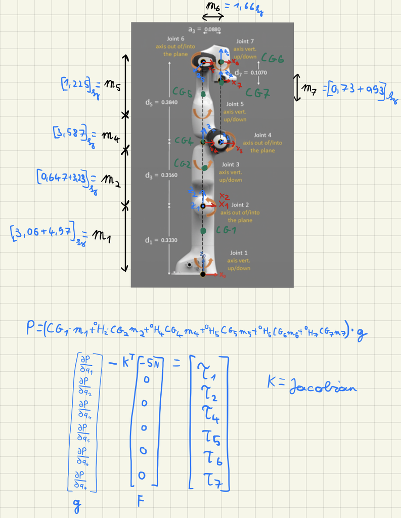

```python
Image("HW5.png")
```

Based on the signs above I created 6 different links, and calculated their mass based on the panda_arm.xacro and hand.xacro files. Since I could not open the given CAD files properly I picked their place and marked them in their local frames, using the corresponding transformation matrices the Potential energy was calculated, also the external force vector was written up according to the description.

```python
m_1=4.97+3.06
m_2=3.228+0.646
m_4=3.58
m_5=1.225
m_6=1.666
m_7=0.73+0.93

m1,m2,m3,m4,m5,m6,m7=symbols('m_1 m_2 m_3 m_4 m_5 m_6 m_7') #symbols
CG1=Matrix([[0],[0],[33.3/2],[1]])
CG2=Matrix([[0],[0],[31.6/2],[1]])
CG4=Matrix([[0],[0],[0],[1]]) #the motor seems heavy so I put the CG to the origo
CG5=Matrix([[0],[38.4/2],[0],[1]]) # this choice is an assumption to make the calculations easier
CG6=Matrix([[0],[0],[0],[1]])
CG7=Matrix([[0],[0],[0],[1]]) #the last link and the end effector has approxiatelly the same weight so I put the CG in the origo
g=9.8

P=((CG1*m1+H_02*CG2*m2+H_04*CG4*m4+H_05*CG5*m5+H_06*CG6*m6+H_07*CG7*m7)*g).subs({q3:0})
P
```

$\displaystyle \left[\begin{matrix}- 154.84 m_{2} \sin{\left(q_{2} \right)} \cos{\left(q_{1} \right)} + 9.8 m_{4} \left(- a_{3} \sin{\left(q_{2} \right)} \sin{\left(q_{4} \right)} \cos{\left(q_{1} \right)} - a_{3} \cos{\left(q_{1} \right)} \cos{\left(q_{2} \right)} \cos{\left(q_{4} \right)} + a_{3} \cos{\left(q_{1} \right)} \cos{\left(q_{2} \right)} - d_{3} \sin{\left(q_{2} \right)} \cos{\left(q_{1} \right)}\right) + 9.8 m_{5} \left(- a_{3} \sin{\left(q_{2} \right)} \sin{\left(q_{4} \right)} \cos{\left(q_{1} \right)} - a_{3} \cos{\left(q_{1} \right)} \cos{\left(q_{2} \right)} \cos{\left(q_{4} \right)} + a_{3} \cos{\left(q_{1} \right)} \cos{\left(q_{2} \right)} - d_{3} \sin{\left(q_{2} \right)} \cos{\left(q_{1} \right)} + d_{5} \left(- \sin{\left(q_{2} \right)} \cos{\left(q_{1} \right)} \cos{\left(q_{4} \right)} + \sin{\left(q_{4} \right)} \cos{\left(q_{1} \right)} \cos{\left(q_{2} \right)}\right) - 19.2 \sin{\left(q_{2} \right)} \cos{\left(q_{1} \right)} \cos{\left(q_{4} \right)} + 19.2 \sin{\left(q_{4} \right)} \cos{\left(q_{1} \right)} \cos{\left(q_{2} \right)}\right) + 9.8 m_{6} \left(a_{3} \left(\left(\sin{\left(q_{2} \right)} \sin{\left(q_{4} \right)} \cos{\left(q_{1} \right)} + \cos{\left(q_{1} \right)} \cos{\left(q_{2} \right)} \cos{\left(q_{4} \right)}\right) \cos{\left(q_{5} \right)} - \sin{\left(q_{1} \right)} \sin{\left(q_{5} \right)}\right) \cos{\left(q_{6} \right)} + a_{3} \left(- \sin{\left(q_{2} \right)} \cos{\left(q_{1} \right)} \cos{\left(q_{4} \right)} + \sin{\left(q_{4} \right)} \cos{\left(q_{1} \right)} \cos{\left(q_{2} \right)}\right) \sin{\left(q_{6} \right)} - a_{3} \sin{\left(q_{2} \right)} \sin{\left(q_{4} \right)} \cos{\left(q_{1} \right)} - a_{3} \cos{\left(q_{1} \right)} \cos{\left(q_{2} \right)} \cos{\left(q_{4} \right)} + a_{3} \cos{\left(q_{1} \right)} \cos{\left(q_{2} \right)} - d_{3} \sin{\left(q_{2} \right)} \cos{\left(q_{1} \right)} + d_{5} \left(- \sin{\left(q_{2} \right)} \cos{\left(q_{1} \right)} \cos{\left(q_{4} \right)} + \sin{\left(q_{4} \right)} \cos{\left(q_{1} \right)} \cos{\left(q_{2} \right)}\right)\right) + 9.8 m_{7} \left(a_{3} \left(\left(\sin{\left(q_{2} \right)} \sin{\left(q_{4} \right)} \cos{\left(q_{1} \right)} + \cos{\left(q_{1} \right)} \cos{\left(q_{2} \right)} \cos{\left(q_{4} \right)}\right) \cos{\left(q_{5} \right)} - \sin{\left(q_{1} \right)} \sin{\left(q_{5} \right)}\right) \cos{\left(q_{6} \right)} + a_{3} \left(- \sin{\left(q_{2} \right)} \cos{\left(q_{1} \right)} \cos{\left(q_{4} \right)} + \sin{\left(q_{4} \right)} \cos{\left(q_{1} \right)} \cos{\left(q_{2} \right)}\right) \sin{\left(q_{6} \right)} - a_{3} \sin{\left(q_{2} \right)} \sin{\left(q_{4} \right)} \cos{\left(q_{1} \right)} - a_{3} \cos{\left(q_{1} \right)} \cos{\left(q_{2} \right)} \cos{\left(q_{4} \right)} + a_{3} \cos{\left(q_{1} \right)} \cos{\left(q_{2} \right)} - d_{3} \sin{\left(q_{2} \right)} \cos{\left(q_{1} \right)} + d_{5} \left(- \sin{\left(q_{2} \right)} \cos{\left(q_{1} \right)} \cos{\left(q_{4} \right)} + \si…

The $g(q)$ vector was calculated below.

```python
G_q=Matrix([[P[2].diff(q1)],[P[2].diff(q2)],[P[2].diff(q4)],[P[2].diff(q5)],[P[2].diff(q6)],[P[2].diff(q7)]])
G_q
```

$\displaystyle \left[\begin{matrix}0\\- 154.84 m_{2} \sin{\left(q_{2} \right)} + 9.8 m_{4} \left(- a_{3} \sin{\left(q_{2} \right)} \sin{\left(q_{4} \right)} - a_{3} \cos{\left(q_{2} \right)} \cos{\left(q_{4} \right)} + a_{3} \cos{\left(q_{2} \right)} - d_{3} \sin{\left(q_{2} \right)}\right) + 9.8 m_{5} \left(- a_{3} \sin{\left(q_{2} \right)} \sin{\left(q_{4} \right)} - a_{3} \cos{\left(q_{2} \right)} \cos{\left(q_{4} \right)} + a_{3} \cos{\left(q_{2} \right)} - d_{3} \sin{\left(q_{2} \right)} + d_{5} \left(- \sin{\left(q_{2} \right)} \cos{\left(q_{4} \right)} + \sin{\left(q_{4} \right)} \cos{\left(q_{2} \right)}\right) - 19.2 \sin{\left(q_{2} \right)} \cos{\left(q_{4} \right)} + 19.2 \sin{\left(q_{4} \right)} \cos{\left(q_{2} \right)}\right) + 9.8 m_{6} \left(a_{3} \left(\sin{\left(q_{2} \right)} \sin{\left(q_{4} \right)} + \cos{\left(q_{2} \right)} \cos{\left(q_{4} \right)}\right) \cos{\left(q_{5} \right)} \cos{\left(q_{6} \right)} + a_{3} \left(- \sin{\left(q_{2} \right)} \cos{\left(q_{4} \right)} + \sin{\left(q_{4} \right)} \cos{\left(q_{2} \right)}\right) \sin{\left(q_{6} \right)} - a_{3} \sin{\left(q_{2} \right)} \sin{\left(q_{4} \right)} - a_{3} \cos{\left(q_{2} \right)} \cos{\left(q_{4} \right)} + a_{3} \cos{\left(q_{2} \right)} - d_{3} \sin{\left(q_{2} \right)} + d_{5} \left(- \sin{\left(q_{2} \right)} \cos{\left(q_{4} \right)} + \sin{\left(q_{4} \right)} \cos{\left(q_{2} \right)}\right)\right) + 9.8 m_{7} \left(a_{3} \left(\sin{\left(q_{2} \right)} \sin{\left(q_{4} \right)} + \cos{\left(q_{2} \right)} \cos{\left(q_{4} \right)}\right) \cos{\left(q_{5} \right)} \cos{\left(q_{6} \right)} + a_{3} \left(- \sin{\left(q_{2} \right)} \cos{\left(q_{4} \right)} + \sin{\left(q_{4} \right)} \cos{\left(q_{2} \right)}\right) \sin{\left(q_{6} \right)} - a_{3} \sin{\left(q_{2} \right)} \sin{\left(q_{4} \right)} - a_{3} \cos{\left(q_{2} \right)} \cos{\left(q_{4} \right)} + a_{3} \cos{\left(q_{2} \right)} - d_{3} \sin{\left(q_{2} \right)} + d_{5} \left(- \sin{\left(q_{2} \right)} \cos{\left(q_{4} \right)} + \sin{\left(q_{4} \right)} \cos{\left(q_{2} \right)}\right) - d_{7} \left(\left(- \sin{\left(q_{2} \right)} \sin{\left(q_{4} \right)} - \cos{\left(q_{2} \right)} \cos{\left(q_{4} \right)}\right) \sin{\left(q_{6} \right)} \cos{\left(q_{5} \right)} + \left(- \sin{\left(q_{2} \right)} \cos{\left(q_{4} \right)} + \sin{\left(q_{4} \right)} \cos{\left(q_{2} \right)}\right) \cos{\left(q_{6} \right)}\right)\right)\\9.8 m_{4} \left(a_{3} \sin{\left(q_{2} \right)} \sin{\left(q_{4} \right)} + a_{3} \cos{\left(q_{2} \right)} \cos{\left(q_{4} \right)}\right) + 9.8 m_{5} \left(a_{3} \sin{\left(q_{2} \right)} \sin{\left(q_{4} \right)} + a_{3} \cos{\left(q_{2} \right)} \cos{\left(q_{4} \right)} + d_{5} \left(\sin{\left(q_{2} \right)} \cos{\left(q_{4} \right)} - \sin{\left(q_{4} \right)} \cos{\left(q_{2} \right)}\right) + 19.2 \sin{\left(q_{2} \right)} \cos{\left(q_{4} \right)} - 19.2 \sin{\left(q_{4} \right)} \cos{\left(q_{2} \right)}\right) + 9.8 m_{6} \left(a_{3} \le…

The mass values are substituted.

```python
G_q=G_q.subs({m1:m_1,m2:m_2,m4:m_4,m5:m_5,m6:m_6,m7:m_7,d1:33.3,d3:31.6,d5:38.4,a3:8.8,d7:20.7})
F=Matrix([[-5],[0],[0],[0],[0],[0]])
G_q
```

$\displaystyle \left[\begin{matrix}0\\- 336.7476 \left(- \sin{\left(q_{2} \right)} \sin{\left(q_{4} \right)} - \cos{\left(q_{2} \right)} \cos{\left(q_{4} \right)}\right) \sin{\left(q_{6} \right)} \cos{\left(q_{5} \right)} + 286.83424 \left(\sin{\left(q_{2} \right)} \sin{\left(q_{4} \right)} + \cos{\left(q_{2} \right)} \cos{\left(q_{4} \right)}\right) \cos{\left(q_{5} \right)} \cos{\left(q_{6} \right)} + 286.83424 \left(- \sin{\left(q_{2} \right)} \cos{\left(q_{4} \right)} + \sin{\left(q_{4} \right)} \cos{\left(q_{2} \right)}\right) \sin{\left(q_{6} \right)} - 336.7476 \left(- \sin{\left(q_{2} \right)} \cos{\left(q_{4} \right)} + \sin{\left(q_{4} \right)} \cos{\left(q_{2} \right)}\right) \cos{\left(q_{6} \right)} - 701.21744 \sin{\left(q_{2} \right)} \sin{\left(q_{4} \right)} - 1943.12832 \sin{\left(q_{2} \right)} \cos{\left(q_{4} \right)} - 3117.85824 \sin{\left(q_{2} \right)} + 1943.12832 \sin{\left(q_{4} \right)} \cos{\left(q_{2} \right)} - 701.21744 \cos{\left(q_{2} \right)} \cos{\left(q_{4} \right)} + 701.21744 \cos{\left(q_{2} \right)}\\286.83424 \left(- \sin{\left(q_{2} \right)} \sin{\left(q_{4} \right)} - \cos{\left(q_{2} \right)} \cos{\left(q_{4} \right)}\right) \cos{\left(q_{5} \right)} \cos{\left(q_{6} \right)} - 336.7476 \left(\sin{\left(q_{2} \right)} \sin{\left(q_{4} \right)} + \cos{\left(q_{2} \right)} \cos{\left(q_{4} \right)}\right) \sin{\left(q_{6} \right)} \cos{\left(q_{5} \right)} + 286.83424 \left(\sin{\left(q_{2} \right)} \cos{\left(q_{4} \right)} - \sin{\left(q_{4} \right)} \cos{\left(q_{2} \right)}\right) \sin{\left(q_{6} \right)} - 336.7476 \left(\sin{\left(q_{2} \right)} \cos{\left(q_{4} \right)} - \sin{\left(q_{4} \right)} \cos{\left(q_{2} \right)}\right) \cos{\left(q_{6} \right)} + 701.21744 \sin{\left(q_{2} \right)} \sin{\left(q_{4} \right)} + 1943.12832 \sin{\left(q_{2} \right)} \cos{\left(q_{4} \right)} - 1943.12832 \sin{\left(q_{4} \right)} \cos{\left(q_{2} \right)} + 701.21744 \cos{\left(q_{2} \right)} \cos{\left(q_{4} \right)}\\336.7476 \left(- \sin{\left(q_{2} \right)} \cos{\left(q_{4} \right)} + \sin{\left(q_{4} \right)} \cos{\left(q_{2} \right)}\right) \sin{\left(q_{5} \right)} \sin{\left(q_{6} \right)} - 286.83424 \left(\sin{\left(q_{2} \right)} \cos{\left(q_{4} \right)} - \sin{\left(q_{4} \right)} \cos{\left(q_{2} \right)}\right) \sin{\left(q_{5} \right)} \cos{\left(q_{6} \right)}\\336.7476 \left(\sin{\left(q_{2} \right)} \sin{\left(q_{4} \right)} + \cos{\left(q_{2} \right)} \cos{\left(q_{4} \right)}\right) \sin{\left(q_{6} \right)} + 286.83424 \left(\sin{\left(q_{2} \right)} \sin{\left(q_{4} \right)} + \cos{\left(q_{2} \right)} \cos{\left(q_{4} \right)}\right) \cos{\left(q_{6} \right)} - 336.7476 \left(- \sin{\left(q_{2} \right)} \cos{\left(q_{4} \right)} + \sin{\left(q_{4} \right)} \cos{\left(q_{2} \right)}\right) \cos{\left(q_{5} \right)} \cos{\left(q_{6} \right)} - 286.83424 \left(\sin{\left(q_{2} \right)} \cos{\left(q_{4} \right)} - \sin{\left(q_{4} \right)} \cos{\left(q_{2} \right)}\right) \sin{\left(q_…

Running a loop to calculate to do the inverse kinematics, first calculate the velocity vector, from that using the inverse Jacobian we get $\dot{q}$, by numerical integration we get $q$ and using the transformation matrix we calculate the $Y,Z$ coordiantes in each iteration. The code is pretty much the same as it was in HW4 just the time is adjusted and there is a torque calculation extension. In each cycle the $\tau$ values are calculated based on the matrix equation written up on the figure above, the values are plotted below. The loop runs for a while but the results seem reasonable and the circle looks nice.

```python
theta_dot=2*pi/200
t=0
V=Matrix([[0],[0],[0],[0],[0],[0]])
Q=Matrix([[0.0],[0.0],[pi/2],[0.0],[pi],[0.0]])
i=0
r=10
x=[]
y=[]
z=[]
tau_1=[]
tau_2=[]
tau_4=[]
tau_5=[]
tau_6=[]
tau_7=[]
time=[]
Tau=Matrix([[0],[0],[0],[0],[0],[0]])
Plot=Matrix([[0],[0],[0],[0]])
A=H_07_inv.col(-1)
while(i<=200):

    V[1]=(-r*sin(pi/2+theta_dot*i)*theta_dot).evalf()
    V[2]=(r*cos(pi/2+theta_dot*i)*theta_dot).evalf()
    #print(Plot[2])
    #Plot=(H_07_inv.col(-1)).subs({q1:Q[0],q2:Q[1],q4:Q[2],q5:Q[3],q6:Q[4],q7:Q[5]}).evalf()
    K=M.subs({q1:Q[0],q2:Q[1],q4:Q[2],q5:Q[3],q6:Q[4],q7:Q[5]}).evalf()
    Q_dot=K.inv().evalf()*V
    Q=Q+1*Q_dot

    Tau = G_q.subs({q1:Q[0],q2:Q[1],q4:Q[2],q5:Q[3],q6:Q[4],q7:Q[5]}).evalf()-K.T*F
    tau_1.append(Tau[0]/100)
    tau_2.append(Tau[1]/100)
    tau_4.append(Tau[2]/100)
    tau_5.append(Tau[3]/100)
    tau_6.append(Tau[4]/100)
    tau_7.append(Tau[5]/100)
    time.append(i)

    #Q[0]=Q[0]+0.25*Q_dot[0]
    #Q[1]=Q[1]+0.25*Q_dot[1]
    #Q[2]=Q[2]+0.25*Q_dot[2]
    #Q[3]=Q[3]+0.25*Q_dot[3]
    #Q[4]=Q[4]+0.25*Q_dot[4]
    #Q[5]=Q[5]+0.25*Q_dot[5]
    Plot=(A.subs({q1:Q[0],q2:Q[1],q4:Q[2],q5:Q[3],q6:Q[4],q7:Q[5]})).evalf()
    x.append(Plot[0])
    y.append(Plot[1])
    z.append(Plot[2])
    ## 2D plot essentials
    #print(Plot[2])
    #plt.plot(Plot[0],Plot[1], Plot[2], color='green', linestyle='solid', linewidth = 3,
     #    marker='o')
    #
    i=i+1
```

```
(-2.0, 2.0)
```

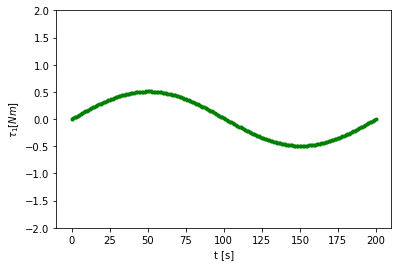

```python
plt.plot(time,tau_1, color='green', linestyle='solid', linewidth = 1,
        marker='.')
plt.ylabel('$\\tau_1 [Nm]$')
plt.xlabel('t [s]')
plt.ylim((-2,2))
```

```
(25.0, 30.0)
```

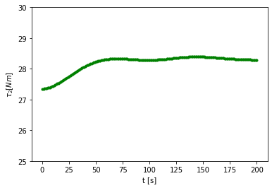

```python
plt.plot(time,tau_2, color='green', linestyle='solid', linewidth = 1,
        marker='.')
plt.ylabel('$\\tau_2 [Nm]$')
plt.xlabel('t [s]')
plt.ylim((25,30))
```

```
(-25.0, -20.0)
```

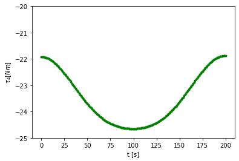

```python
plt.plot(time,tau_4, color='green', linestyle='solid', linewidth = 1,
        marker='.')
plt.ylabel('$\\tau_4 [Nm]$')
plt.xlabel('t [s]')
plt.ylim((-25,-20))
```

```
(-5.0, 5.0)
```

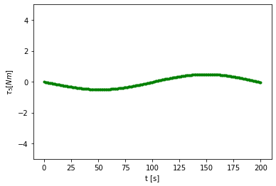

```python
plt.plot(time,tau_5, color='green', linestyle='solid', linewidth = 1,
        marker='.')
plt.ylabel('$\\tau_5 [Nm]$')
plt.xlabel('t [s]')
plt.ylim((-5,5))
```

```
(0.0, 5.0)
```

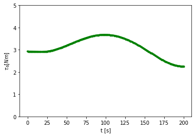

```python
plt.plot(time,tau_6, color='green', linestyle='solid', linewidth = 3,
        marker='.')
plt.ylabel('$\\tau_6 [Nm]$')
plt.xlabel('t [s]')
plt.ylim((0,5))
```

```
(-1.0, 1.0)
```

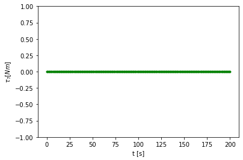

```python
plt.plot(time,tau_7, color='green', linestyle='solid', linewidth = 1,
        marker='.')
plt.ylabel('$\\tau_7 [Nm]$')
plt.xlabel('t [s]')
plt.ylim((-1,1))
```

3D plot

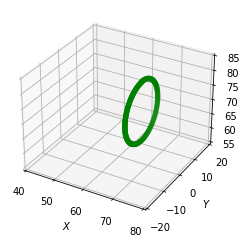

```python
ax = plt.axes(projection='3d')
ax.set_aspect('equal','box')
ax.axes.set_xlim3d(left=40, right=80)
ax.axes.set_ylim3d(bottom=-20, top=20)
ax.axes.set_zlim3d(bottom=55, top=85)
ax.scatter3D(x, y, z, color='green');
ax.set_xlabel('$X$')
ax.set_ylabel('$Y$')
```